# 2019-01-24-Broom

Broom est un package qui fait partie du **Tidyverse**, ce package permet de présenter de manière simple et conviviale les résultats d'une analyse de donnée. La meilleure façon est de le voir en action

```r
options(warn = -1)
```

```r
library(tidyverse)
```

Ce package ne vient pas nativement avec Tidyverse, donc il faudra l'installer indépendemment.

```r
# install.packages("broom")
```

```r
library(broom)
```

Importons une base de donnée et réalisons une regression linéaire.

```r
fortune <- read.csv("fortune1000.csv")
```

```r
fortune %>% head()
```

| Rank | Company | Sector | Industry | Location | Revenue | Profits | Employees |
| --- | --- | --- | --- | --- | --- | --- | --- |
| 1 | Walmart | Retailing | General Merchandisers | Bentonville, AR | 482130 | 14694 | 2300000 |
| 2 | Exxon Mobil | Energy | Petroleum Refining | Irving, TX | 246204 | 16150 | 75600 |
| 3 | Apple | Technology | Computers, Office Equipment | Cupertino, CA | 233715 | 53394 | 110000 |
| 4 | Berkshire Hathaway | Financials | Insurance: Property and Casualty (Stock) | Omaha, NE | 210821 | 24083 | 331000 |
| 5 | McKesson | Health Care | Wholesalers: Health Care | San Francisco, CA | 181241 | 1476 | 70400 |
| 6 | UnitedHealth Group | Health Care | Health Care: Insurance and Managed Care | Minnetonka, MN | 157107 | 5813 | 200000 |

Maintenons, on veut essayer d'expliquer le profit en prenant comme variables explicatives `Employees`, `Revenue`, et `Industrie`

```r
base_reg <- fortune %>% select(c(Employees, Profits, Industry, Revenue))
```

```r
base_reg %>% head(4)
```

| Employees | Profits | Industry | Revenue |
| --- | --- | --- | --- |
| 2300000 | 14694 | General Merchandisers | 482130 |
| 75600 | 16150 | Petroleum Refining | 246204 |
| 110000 | 53394 | Computers, Office Equipment | 233715 |
| 331000 | 24083 | Insurance: Property and Casualty (Stock) | 210821 |

```r
modele <- lm(Profits~., data = base_reg)
```

## La force de `broom`, la fonction `tidy()`

Arrivé ici normalement ce qu'on fait normalement c'est afficher les résultats à l'aide de la fonction `summary()`, ou accéder directement aux éléments enregistrés dans l'objet `modele` avec la commande `names()`.

```r
names(modele)
```

1. 'coefficients'

2. 'residuals'

3. 'effects'

4. 'rank'

5. 'fitted.values'

6. 'assign'

7. 'qr'

8. 'df.residual'

9. 'contrasts'

10. 'xlevels'

11. 'call'

12. 'terms'

13. 'model'

Ce que Broom fait c'est d'accéder aux élements contenus dans le modèle et les transformer en `tidy data` afin qu'on accède directement. Si on avait fait `summary(modele)` alors on aurait beaucoup de lignes de résultats bruts, sans pouvoir les exploiter autrement que de lire et interpréter.  
La fonction `tidy` de broom régler ce problème et met dans une `data.frame` les résultas destinés à l'interprétation afin de nous permettre de les accéder directement. Voyons un exemple

```r
# la classe de l'objet lorsqu'on le passe à travers tidy()
modele %>% tidy() %>% class()
```

1. 'tbl_df'

2. 'tbl'

3. 'data.frame'

Il s'agit d'un objet qui hérite des propriétés d'un `tibble` et des `data.frame` R, ce faisant nous pouvons appliquer toutes les fonctions qui marchent sur ces objets.

```r
modele %>% tidy() %>% head(10)
```

| term | estimate | std.error | statistic | p.value |
| --- | --- | --- | --- | --- |
| (Intercept) | 301.52593459 | 1.600633e+03 | 0.18837917 | 8.506207e-01 |
| Employees | -0.00975562 | 1.367335e-03 | -7.13476791 | 1.956699e-12 |
| IndustryAerospace and Defense | -88.94838014 | 1.678233e+03 | -0.05300122 | 9.577424e-01 |
| IndustryAirlines | 1093.05968096 | 1.769090e+03 | 0.61786551 | 5.368161e-01 |
| IndustryApparel | -133.72017543 | 1.703369e+03 | -0.07850337 | 9.374446e-01 |
| IndustryAutomotive Retailing, Services | -954.92509638 | 1.753334e+03 | -0.54463376 | 5.861367e-01 |
| IndustryBeverages | 377.72817692 | 1.769049e+03 | 0.21352052 | 8.309680e-01 |
| IndustryBuilding Materials, Glass | -230.69135851 | 1.814484e+03 | -0.12713881 | 8.988582e-01 |
| IndustryChemicals | -167.23971767 | 1.652945e+03 | -0.10117680 | 9.194320e-01 |
| IndustryCommercial Banks | 2757.30593617 | 1.656604e+03 | 1.66443296 | 9.636461e-02 |

On a donc un meilleur contrôle de ces résultats car j'ai choisi ici de n'afficher que les 10 premières lignes. Je peux aller encore plus loin en représentant graphiquement les p-values, par exemple pour voir sur nos variables la proportion de celles qui sont significatives.

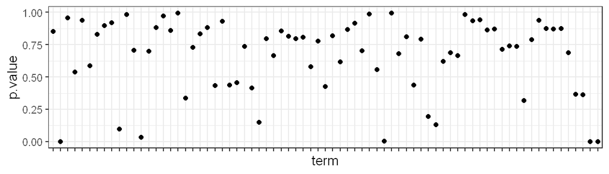

```r
options(repr.plot.res = 180, repr.plot.height = 2)
modele %>% tidy %>% ggplot(aes(x= term, y= p.value)) + geom_point() + theme_bw() +
  theme(axis.text.x=element_blank())
```

On peut maintenant enregistrer le data.frame et effectuer les opérations normales qu'on fait avec une base de donnée

```r
resultats_modele <- modele %>% tidy()
```

Maintenant, trions uniquement les `p-value` inférieures au seuil de 5%

```r
resultats_modele %>% filter(p.value <0.05)
```

| term | estimate | std.error | statistic | p.value |
| --- | --- | --- | --- | --- |
| Employees | -9.755620e-03 | 1.367335e-03 | -7.134768 | 1.956699e-12 |
| IndustryComputers, Office Equipment | 3.906947e+03 | 1.820724e+03 | 2.145821 | 3.214694e-02 |
| IndustryMining, Crude-Oil Production | -5.295356e+03 | 1.656938e+03 | -3.195868 | 1.441359e-03 |
| IndustryWholesalers: Health Care | -6.511361e+03 | 1.871532e+03 | -3.479162 | 5.264516e-04 |
| Revenue | 9.480484e-02 | 4.183855e-03 | 22.659685 | 9.000024e-91 |

On voit donc les variables modalités qui sont signifiatives dans l'interprétation de notre modèle.

## La fonction `augment()`

L'objet `modele` qu'on vient de créer a des méthodes qui s'appliquent directement sur lui comme la fonction plot qui nous représente graphiquement les résultats de l'estimation, mais la fonction `plot()` ne nous permet de modifier comment les choses se présentent, on aimerait donc avoir une base de donnée qu'on va pouvoir manipuler. C'est alors que vient la fonction `augment()` du package **`broom`**.

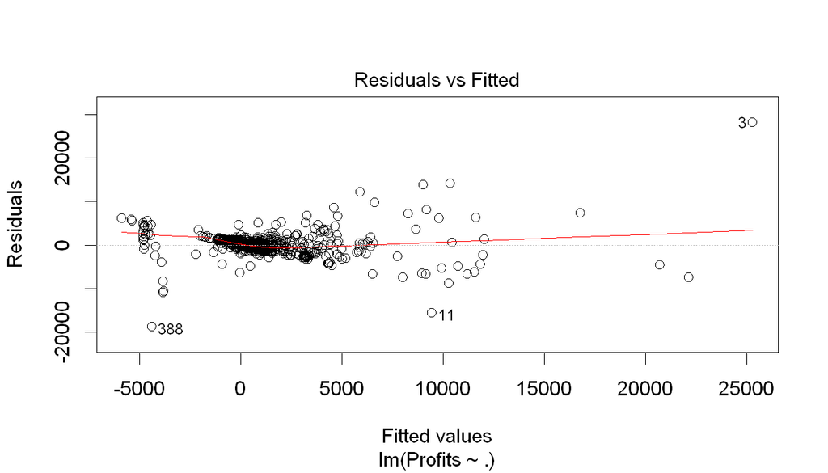

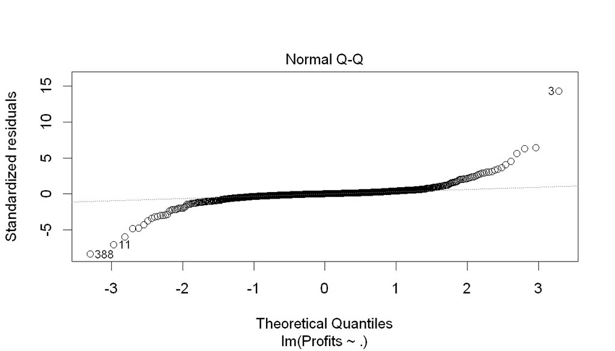

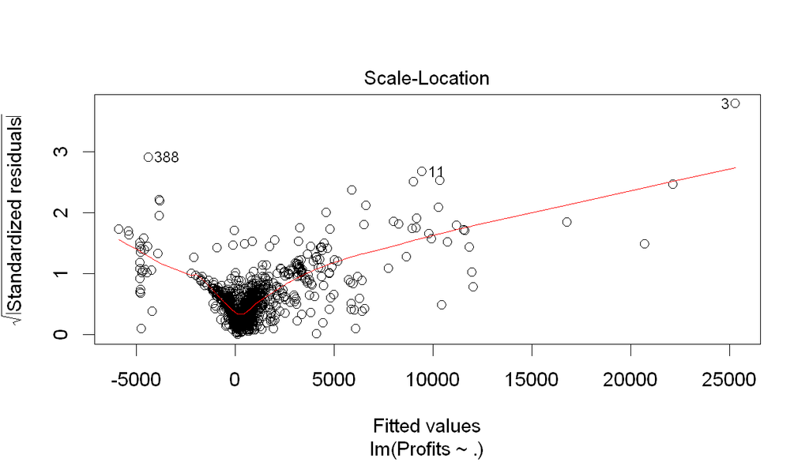

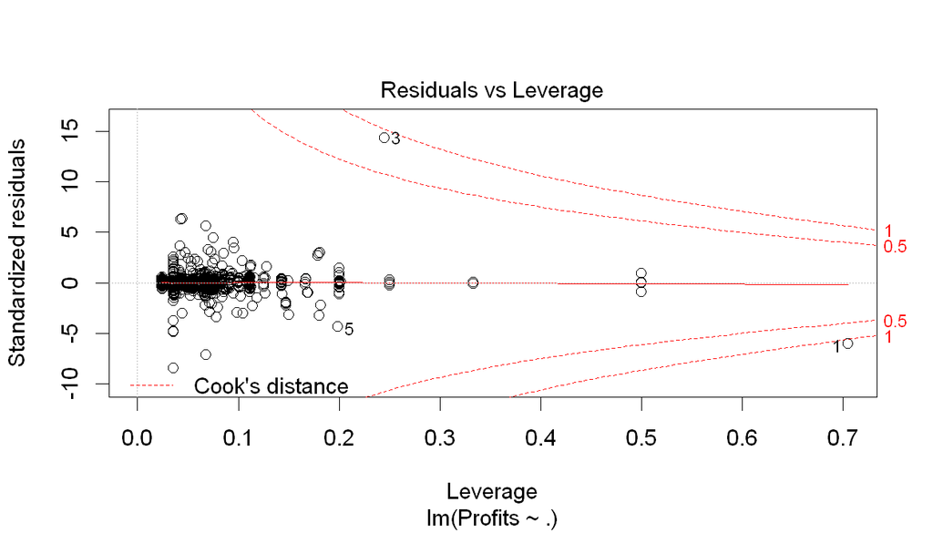

```r
options(repr.plot.res = 180, repr.plot.height = 4)
plot(modele)
```

Ces graphiques représentent les résultats contenus dans notre objet `modele`, or avec la fonction `augment` on peut faire quelque chose d'intéressant.

```r
autres_resultats <- modele %>% augment()
```

```r
autres_resultats %>% head()
```

| Profits | Employees | Industry | Revenue | .fitted | .se.fit | .resid | .hat | .sigma | .cooksd | .std.resid |
| --- | --- | --- | --- | --- | --- | --- | --- | --- | --- | --- |
| 14694 | 2300000 | General Merchandisers | 482130 | 22121.16 | 1900.1094 | -7427.161 | 0.70551132 | 2218.166 | 1.16922462 | -6.050091 |
| 16150 | 75600 | Petroleum Refining | 246204 | 20685.85 | 965.5171 | -4535.853 | 0.18216574 | 2257.379 | 0.01459955 | -2.217174 |
| 53394 | 110000 | Computers, Office Equipment | 233715 | 25292.67 | 1119.3419 | 28101.332 | 0.24483434 | 1997.814 | 0.88333858 | 14.294836 |
| 24083 | 331000 | Insurance: Property and Casualty (Stock) | 210821 | 16778.98 | 699.3779 | 7304.025 | 0.09558078 | 2249.254 | 0.01624206 | 3.395086 |
| 1476 | 70400 | Wholesalers: Health Care | 181241 | 10285.89 | 1008.0009 | -8809.893 | 0.19854943 | 2240.129 | 0.06250892 | -4.350164 |
| 5813 | 200000 | Health Care: Insurance and Managed Care | 157107 | 10720.84 | 764.5943 | -4907.842 | 0.11423756 | 2256.890 | 0.00913779 | -2.305183 |

Ici, on a notre base de donnée initiale, augmenté des résultats statistiques associées à chacune des observations.

Nous avons également dans ce même data.frame, la valeur prédite, appelée ici **.fitted**. On peut donc à partir de ça faire une représentation graphique pour visuellement voir la performance du modèle.

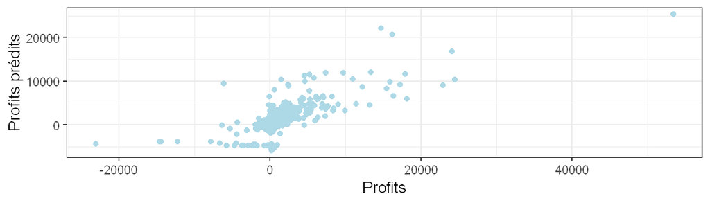

```r
options(repr.plot.res = 180, repr.plot.height = 2)
autres_resultats %>% ggplot(aes(x= Profits, y = .fitted)) +
geom_point(col = "lightblue") + ylab("Profits prédits") + theme_bw()
```

On voit donc les possibilités que ce package nous offre en terme de flexibilité

On peut aussi facilement représenter les *hat values* et la *distance de Cooks*

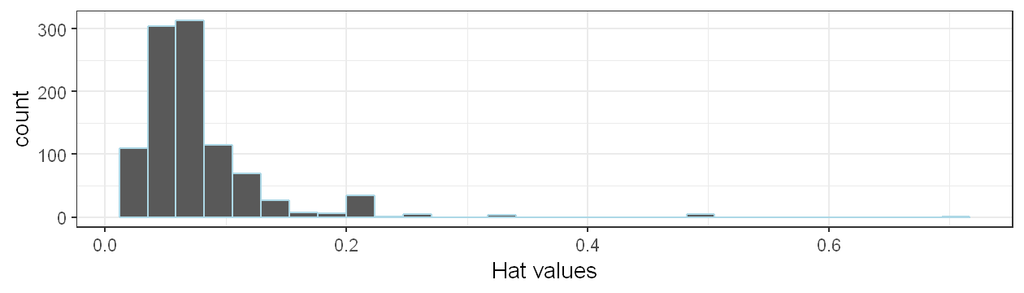

```r
autres_resultats %>% ggplot(aes(x= .hat)) +
geom_histogram(col = "lightblue", bins = 30) + theme_bw() + xlab("Hat values")
```

On voit qu'il y a certaines observations qui ont une valeur supérieure à 0.3, facilement on peut les repérer.

```r
autres_resultats %>% filter(.hat >0.3)
```

| Profits | Employees | Industry | Revenue | .fitted | .se.fit | .resid | .hat | .sigma | .cooksd | .std.resid |
| --- | --- | --- | --- | --- | --- | --- | --- | --- | --- | --- |
| 14694 | 2300000 | General Merchandisers | 482130 | 22121.160739 | 1900.109 | -7427.16074 | 0.7055113 | 2218.166 | 1.169225e+00 | -6.05009110 |
| 4844 | 341240 | Mail, Package, and Freight Delivery | 58363 | 3375.359880 | 1599.677 | 1468.64012 | 0.5000474 | 2262.369 | 1.124268e-02 | 0.91817266 |
| 1050 | 323035 | Mail, Package, and Freight Delivery | 47453 | 2518.640120 | 1599.677 | -1468.64012 | 0.5000474 | 2262.369 | 1.124268e-02 | -0.91817266 |
| 1094 | 74900 | Advertising, marketing | 15134 | 1005.606490 | 1599.643 | 88.39351 | 0.5000263 | 2263.397 | 4.072159e-05 | 0.05526118 |
| 455 | 49200 | Advertising, marketing | 7614 | 543.393510 | 1599.643 | -88.39351 | 0.5000263 | 2263.397 | 4.072159e-05 | -0.05526118 |
| -101 | 11585 | Education | 2984 | 108.382045 | 1306.088 | -209.38205 | 0.3333433 | 2263.385 | 8.567453e-05 | -0.11336049 |
| 30 | 23400 | Education | 2591 | -44.138902 | 1306.110 | 74.13890 | 0.3333544 | 2263.399 | 1.074222e-05 | 0.04013951 |
| 140 | 11770 | Education | 1910 | 4.756857 | 1306.074 | 135.24314 | 0.3333360 | 2263.394 | 3.574245e-05 | 0.07322091 |

## La fonction `glance()`

Une autre fonction de ce package est la fonction `glance`, de l'anglais (coup d'oeil), qui nous permet de rapidement avoir à disposition certaines valeurs et indicateurs tels le R², les critères AIC et BIC ...

```r
modele %>% glance()
```

| r.squared | adj.r.squared | sigma | statistic | p.value | df | logLik | AIC | BIC | deviance | df.residual |
| --- | --- | --- | --- | --- | --- | --- | --- | --- | --- | --- |
| 0.5641121 | 0.5292411 | 2262.177 | 16.1771 | 1.861538e-121 | 75 | -9104.041 | 18360.08 | 18733.07 | 4733636972 | 925 |

Donc voilà !!

Le tidyverse a été bien pensé pour faciliter l'utilisation de R et ce package `broom` vient ajouter une autre dimension au traitement des résultats que nous donne le modèle. Bien entendu, dans cet exemple j'ai fait une regression linéaire, mais les mêmes fonctions s'appliquent à tous les modèles que vous serez amenés à stocker dans une variable !! Donc à vous maintenant d'utiliser **`broom`** !!

Dernier mis à jour : 10 Mars 2019